# Exercise 3

Adam Lu

2018/3/12

```r
library(dplyr)
library(survival)
library(survminer)
library(RTCGA)
library(RTCGA.clinical)
```

The **“KIPAN”** cohort (in `KIPAN.clinical`) is the pan-kidney cohort, consisting of KICH (chromaphobe renal cell carcinoma), KIRC (renal clear cell carcinoma), and KIRP (papillary cell carcinoma). The `KIPAN.clinical` has `KICH.clinical`, `KIRC.clinical`, and `KIPR.clinical` all combined.

1. Using `survivalTCGA()`, create a new object called `clinkid` using the `KIPAN.clinical` cohort. For the columns to extract, get both the disease code and the patient’s gender (`extract.cols=c("admin.disease_code", "patient.gender")`). The first few rows will look like this.

```r
clinkid <- survivalTCGA(KIPAN.clinical,
                        extract.cols = c("admin.disease_code",
                                         "patient.gender"))
head(clinkid)
```

```
##   times bcr_patient_barcode patient.vital_status admin.disease_code
## 1  1158        TCGA-KL-8323                    1               kich
## 2  4311        TCGA-KL-8324                    0               kich
## 3   725        TCGA-KL-8325                    1               kich
## 4  3322        TCGA-KL-8326                    0               kich
## 5  3553        TCGA-KL-8327                    0               kich
## 6  3127        TCGA-KL-8328                    0               kich
##   patient.gender
## 1         female
## 2         female
## 3         female
## 4           male
## 5         female
## 6           male
```

2. The xtabs() command will produce tables of counts for categorical variables. Use this command to examine how many samples you have for each kidney sample type, separately by sex.

```r
xtabs(~ admin.disease_code + patient.gender, data = clinkid)
```

```
##                   patient.gender
## admin.disease_code female male
##               kich     51   61
##               kirc    191  346
##               kirp     76  212
```

3. Run a Cox PH regression on the cancer type and gender. What’s the effect of gender? Is it significant? How does survival differ by each type? Which has the worst prognosis?

```r
coxph(Surv(times, patient.vital_status) ~
              admin.disease_code + patient.gender, data = clinkid)
```

```
## Call:
## coxph(formula = Surv(times, patient.vital_status) ~ admin.disease_code +
##     patient.gender, data = clinkid)
##
##                           coef exp(coef) se(coef)     z       p
## admin.disease_codekirc  1.5929    4.9179   0.3450  4.62 3.9e-06
## admin.disease_codekirp  0.9962    2.7080   0.3807  2.62  0.0089
## patient.gendermale     -0.0628    0.9391   0.1484 -0.42  0.6721
##
## Likelihood ratio test=39.4  on 3 df, p=1.4e-08
## n= 937, number of events= 203
```

[output not shown]

4. Create survival curves for each different subtype.
   1. Produce a Kaplan-Meier plot.

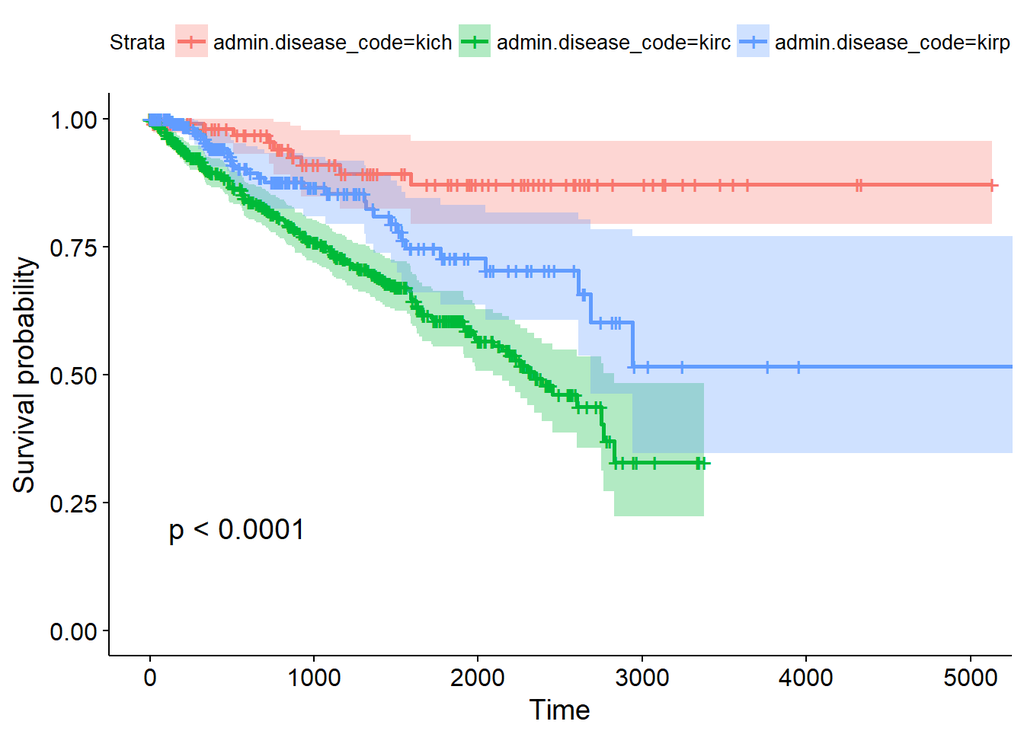

[output not shown]

```r
sfit <-
    survfit(Surv(times, patient.vital_status) ~ admin.disease_code,
            data = clinkid)

ggsurvplot(sfit, conf.int = TRUE, pval = TRUE)
```

```r
summary(sfit, times=seq(0, 365*5, 365))
```

```
## Call: survfit(formula = Surv(times, patient.vital_status) ~ admin.disease_code,
##     data = clinkid)
##
##                 admin.disease_code=kich
##  time n.risk n.event survival std.err lower 95% CI upper 95% CI
##     0    111       0    1.000  0.0000        1.000        1.000
##   365     86       2    0.980  0.0144        0.952        1.000
##   730     72       2    0.954  0.0226        0.911        0.999
##  1095     54       3    0.910  0.0329        0.848        0.977
##  1460     44       1    0.893  0.0366        0.824        0.967
##  1825     38       1    0.871  0.0415        0.794        0.957
##
##                 admin.disease_code=kirc
##  time n.risk n.event survival std.err lower 95% CI upper 95% CI
##     0    536       0    1.000  0.0000        1.000        1.000
##   365    385      49    0.895  0.0142        0.868        0.924
##   730    313      32    0.816  0.0186        0.781        0.853
##  1095    250      26    0.744  0.0217        0.703        0.788
##  1460    181      20    0.678  0.0243        0.633        0.728
##  1825    112      16    0.606  0.0277        0.554        0.663
##
##                 admin.disease_code=kirp
##  time n.risk n.event survival std.err lower 95% CI upper 95% CI
##     0    288       0    1.000  0.0000        1.000        1.000
##   365    145      10    0.941  0.0182        0.906        0.977
##   730    100       8    0.877  0.0278        0.824        0.933
##  1095     67       2    0.853  0.0316        0.793        0.917
##  1460     54       3    0.810  0.0388        0.737        0.889
##  1825     36       5    0.727  0.0495        0.636        0.831
```